# Course Poject 2: The Impact of Various Weather Events on US Population Health and Economy

# 1. Synopsis

The basic goal of this assignment is to explore the U.S. National Oceanic and Atmospheric Administration’s (NOAA) storm database from 1950 to November 2011 and address the following questions:

- Across the United States, which types of events (as indicated in the `EVTYPE` variable) are most harmful with respect to population health?
- Across the United States, which types of events have the greatest economic consequences?

# 2. Data Processing

## 2.1 Data Downloading and Reading

Download the data (compressed in bz2 format) from the course website and read the file using `read.csv()` to load the data into R (Note: `read.csv()` can read the .csv file even if it’s compressed in .bz2)

```r
if (!file.exists("repdata_data_StormData.csv.bz2")) {
        download.file("https://d396qusza40orc.cloudfront.net/repdata%2Fdata%2FStormData.csv.bz2","repdata_data_StormData.csv.bz2")
}

if (!exists("storm")) {
  storm <- read.csv("repdata_data_StormData.csv.bz2")
}
```

## 2.2 Data Exploration

```r
str(storm)
```

```
## 'data.frame':    902297 obs. of  37 variables:
##  $ STATE__   : num  1 1 1 1 1 1 1 1 1 1 ...
##  $ BGN_DATE  : Factor w/ 16335 levels "1/1/1966 0:00:00",..: 6523 6523 4242 11116 2224 2224 2260 383 3980 3980 ...
##  $ BGN_TIME  : Factor w/ 3608 levels "00:00:00 AM",..: 272 287 2705 1683 2584 3186 242 1683 3186 3186 ...
##  $ TIME_ZONE : Factor w/ 22 levels "ADT","AKS","AST",..: 7 7 7 7 7 7 7 7 7 7 ...
##  $ COUNTY    : num  97 3 57 89 43 77 9 123 125 57 ...
##  $ COUNTYNAME: Factor w/ 29601 levels "","5NM E OF MACKINAC BRIDGE TO PRESQUE ISLE LT MI",..: 13513 1873 4598 10592 4372 10094 1973 23873 24418 4598 ...
##  $ STATE     : Factor w/ 72 levels "AK","AL","AM",..: 2 2 2 2 2 2 2 2 2 2 ...
##  $ EVTYPE    : Factor w/ 985 levels "   HIGH SURF ADVISORY",..: 834 834 834 834 834 834 834 834 834 834 ...
##  $ BGN_RANGE : num  0 0 0 0 0 0 0 0 0 0 ...
##  $ BGN_AZI   : Factor w/ 35 levels "","  N"," NW",..: 1 1 1 1 1 1 1 1 1 1 ...
##  $ BGN_LOCATI: Factor w/ 54429 levels "","- 1 N Albion",..: 1 1 1 1 1 1 1 1 1 1 ...
##  $ END_DATE  : Factor w/ 6663 levels "","1/1/1993 0:00:00",..: 1 1 1 1 1 1 1 1 1 1 ...
##  $ END_TIME  : Factor w/ 3647 levels ""," 0900CST",..: 1 1 1 1 1 1 1 1 1 1 ...
##  $ COUNTY_END: num  0 0 0 0 0 0 0 0 0 0 ...
```

[output cut: 23 more lines]

The `str()` function is a very handy tools to explore the data. There are 902297 observations with 37 variables which makes the data difficult to view in one whole screen. To summarize and simplify our dataset, a subset dataset was created `st` containing 8 variables only (“STATE”, “EVTYPE”, “FATALITIES”, “INJURIES”, “PROPDMG”, “PROPDMGEXP”,“CROPDMG”, and “CROPDMGEXP”).

There are 985 different event types on the `EVTYPE` variable. Looking at the `EVTYPE` data, alot of typo errors where observe like TORNDAO instead of TORNADO. Other entries have the same meaning but were recorded differently like FLASH FLOOD and FLOOD/FLASH. Some were written in uppercase and others are in lowercase but only refers to one event type.

The following code performs a text processing, grouping the same weather events as precisely as possible. After processing, there are 262 different event types left, much less than the original number of types, 985.

## 2.3 Subset Needed Variables

```r
# Selecting the needed variables (columns)
st <- storm[, c("STATE", "EVTYPE", "FATALITIES", "INJURIES", "PROPDMG", "PROPDMGEXP","CROPDMG", "CROPDMGEXP")]
```

## 2.4 Cleaning the EVTYPE variable

```r
# Convert lower cases event type to upper class to reduce levels
st$EVTYPE <- factor(toupper(st$EVTYPE))
# EVTYPE levels decreased from 985 to 898 (Use str() function to check)

# Fixing / triming event types that are redundant just like with spaces
trim <- function(x) {gsub("(^[[:space:]]+|[[:space:]]+$)", "", x)}
st$EVTYPE <- factor(trim(st$EVTYPE))
# EVTYPE levels decreased from 898 to 890

# Combining mispelled event types to correct ones using grepl to reduce event types/levels
st[grepl("BLIZZARD", st$EVTYPE), ]$EVTYPE <- "BLIZZARD"
st[grepl("AVALANCE", st$EVTYPE), ]$EVTYPE <- "AVALANCHE"
st[grepl("BRUSH FIRE", st$EVTYPE), ]$EVTYPE <- "BRUSH FIRE"
st[grepl("BLOW-OUT TIDE", st$EVTYPE), ]$EVTYPE <- "BLOW-OUT TIDE"
st[grepl("DRY", st$EVTYPE), ]$EVTYPE <- "DRY"
st[grepl("DROUGHT", st$EVTYPE), ]$EVTYPE <- "DROUGHT"
st[grepl("COASTAL FLOOD", st$EVTYPE), ]$EVTYPE <- "COASTAL FLOOD"
st[(grepl("COLD", st$EVTYPE) & !(grepl("EXTREME COLD", st$EVTYPE)) & !(grepl("EXTREME/RECORD COLD", st$EVTYPE))), ]$EVTYPE <- "COLD"
st[grepl("EXTREME/RECORD COLD", st$EVTYPE), ]$EVTYPE <- "EXTREME COLD"
st[grepl("DUST STORM", st$EVTYPE), ]$EVTYPE <- "DUSTSTORM"
st[grepl("DUST DEVEL", st$EVTYPE), ]$EVTYPE <- "DUST DEVIL"
st[grepl("FLASH FLOOD", st$EVTYPE), ]$EVTYPE <- "FLASH FLOOD"
st[grepl("FLOOD FLASH", st$EVTYPE), ]$EVTYPE <- "FLASH FLOOD"
st[grepl("FLOOD/FLASH", st$EVTYPE), ]$EVTYPE <- "FLASH FLOOD"
st[(grepl("FLOOD", st$EVTYPE) & !(grepl("FLASH FLOOD", st$EVTYPE)) & !(grepl("LAKESHORE FLOOD", st$EVTYPE)) & !(grepl("COASTAL FLOOD", st$EVTYPE))), ]$EVTYPE <- "FLOOD"
st[grepl("FUNNEL", st$EVTYPE), ]$EVTYPE <- "FUNNEL CLOUD"
st[grepl("FROST", st$EVTYPE), ]$EVTYPE <- "FROST/FREEZE"
st[grepl("GLAZE", st$EVTYPE), ]$EVTYPE <- "GLAZE"
st[grepl("HAIL", st$EVTYPE) & !(grepl("MARINE HAIL", st$EVTYPE)), ]$EVTYPE <- "HAIL"
st[grepl("HEAT", st$EVTYPE) & !(grepl("EXCESSIVE HEAT", st$EVTYPE)), ]$EVTYPE <- "HEAT"
st[grepl("HEAVY RAIN", st$EVTYPE), ]$EVTYPE <- "HEAVY RAIN"
st[grepl("HEAVY PRECIPATATION", st$EVTYPE), ]$EVTYPE <- "HEAVY PRECIPITATION"
st[grepl("HIGH  SWELLS", st$EVTYPE), ]$EVTYPE <- "HIGH SWELLS"
st[grepl("HEAVY SHOWERS", st$EVTYPE), ]$EVTYPE <- "HEAVY SHOWER"
st[grepl("HVY RAIN", st$EVTYPE), ]$EVTYPE <- "HEAVY RAIN"
st[grepl("HEAVY SNOW", st$EVTYPE), ]$EVTYPE <- "HEAVY SNOW"
st[grepl("HIGH SURF", st$EVTYPE), ]$EVTYPE <- "HIGH SURF"
st[grepl("HIGH WIND", st$EVTYPE) & !(grepl("MARINE HIGH WIND", st$EVTYPE)), ]$EVTYPE <- "HIGH WIND"
st[grepl("HURRICANE", st$EVTYPE), ]$EVTYPE <- "HURRICANE"
st[grepl("HYPOTHERMIA/EXPOSURE", st$EVTYPE), ]$EVTYPE <- "HYPOTHERMIA"
st[grepl("ICE ON ROAD", st$EVTYPE), ]$EVTYPE <- "ICE ROADS"
st[grepl("ICY ROADS", st$EVTYPE), ]$EVTYPE <- "ICE ROADS"
st[grepl("LANDSLIDES", st$EVTYPE), ]$EVTYPE <- "LANDSLIDE"
st[grepl("LAKE EFFECT SNOW", st$EVTYPE), ]$EVTYPE <- "LAKE-EFFECT SNOW"
st[grepl("LIGHTNING", st$EVTYPE), ]$EVTYPE <- "LIGHTNING"
st[grepl("LIGHTING", st$EVTYPE), ]$EVTYPE <- "LIGHTNING"
st[grepl("LIGNTNING", st$EVTYPE), ]$EVTYPE <- "LIGHTNING"
st[grepl("LOW TEMPERATURE RECORD", st$EVTYPE), ]$EVTYPE <- "LOW TEMPERATURE"
st[grepl("MUD SLIDE", st$EVTYPE), ]$EVTYPE <- "MUDSLIDE"
st[grepl("MUDSLIDE/LANDSLIDE", st$EVTYPE), ]$EVTYPE <- "MUDSLIDE"
st[grepl("MUD/ROCK SLIDE", st$EVTYPE), ]$EVTYPE <- "MUDSLIDE"
# st[grepl("RAIN (HEAVY)", st$EVTYPE), ]$EVTYPE <- "HEAVY RAIN"
st$EVTYPE[289860] <- "HEAVY RAIN"
st[grepl("RIP CURRENT", st$EVTYPE), ]$EVTYPE <- "RIP CURRENT"
st[grepl("RECORD/EXCESSIVE HEAT", st$EVTYPE), ]$EVTYPE <- "EXCESSIVE HEAT"
st[grepl("SMALL STREAM AND", st$EVTYPE), ]$EVTYPE <- "SMALL STREAM"
st[grepl("SML STREAM FLD", st$EVTYPE), ]$EVTYPE <- "SMALL STREAM"
st[grepl("TORRENTIAL RAINFALL", st$EVTYPE), ]$EVTYPE <- "TORRENTIAL RAIN"
st[grepl("THUNDERSTORM WIND", st$EVTYPE) & !(grepl("MARINE THUNDERSTORM WIND", st$EVTYPE)), ]$EVTYPE <- "THUNDERSTORM WIND"
st[grepl("THUDERSTORM WINDS", st$EVTYPE), ]$EVTYPE <- "THUNDERSTORM WIND"
st[grepl("THUNDEERSTORM WINDS", st$EVTYPE), ]$EVTYPE <- "THUNDERSTORM WIND"
st[grepl("THUNDERESTORM WINDS", st$EVTYPE), ]$EVTYPE <- "THUNDERSTORM WIND"
st[grepl("THUNDERSTORM", st$EVTYPE) & !(grepl("MARINE THUNDERSTORM WIND", st$EVTYPE)), ]$EVTYPE <- "THUNDERSTORM WIND"
st[grepl("TUNDERSTORM", st$EVTYPE), ]$EVTYPE <- "THUNDERSTORM WIND"
st[grepl("THUNDERSTROM", st$EVTYPE), ]$EVTYPE <- "THUNDERSTORM WIND"
st[grepl("THUNDERTSORM", st$EVTYPE), ]$EVTYPE <- "THUNDERSTORM WIND"
st[grepl("THUNDERTORM", st$EVTYPE), ]$EVTYPE <- "THUNDERSTORM WIND"
st[grepl("THUNDESTORM", st$EVTYPE), ]$EVTYPE <- "THUNDERSTORM WIND"
st[grepl("THUNERSTORM", st$EVTYPE), ]$EVTYPE <- "THUNDERSTORM WIND"
st[grepl("SNOW", st$EVTYPE), ]$EVTYPE <- "SNOW"
st[grepl("SLEET", st$EVTYPE), ]$EVTYPE <- "SLEET"
st[grepl("STORM SURGE", st$EVTYPE), ]$EVTYPE <- "STORM SURGE"
st[grepl("TYPHOON", st$EVTYPE), ]$EVTYPE <- "HURRICANE"
st[grepl("TSTM", st$EVTYPE), ]$EVTYPE <- "THUNDERSTORM WIND"
st[grepl("TORNADO", st$EVTYPE), ]$EVTYPE <- "TORNADO"
st[grepl("TORNDAO", st$EVTYPE), ]$EVTYPE <- "TORNADO"
st[grepl("UNSEASONABLY WARM YEAR", st$EVTYPE), ]$EVTYPE <- "UNSEASONABLY WARM"
st[grepl("UNUSUAL/RECORD WARMTH", st$EVTYPE), ]$EVTYPE <- "UNUSUAL WARMTH"
st[grepl("UNUSUALLY WARM", st$EVTYPE), ]$EVTYPE <- "UNUSUAL WARMTH"
st[grepl("URBAN", st$EVTYPE), ]$EVTYPE <- "URBAN SMALL"
st[grepl("UNSEASONABLY WARM & WET", st$EVTYPE), ]$EVTYPE <- "UNSEASONABLY WARM/WET"
st[grepl("WET MICOBURST", st$EVTYPE), ]$EVTYPE <- "WET MICROBURST"
st[grepl("VOLCANIC ASH", st$EVTYPE), ]$EVTYPE <- "VOLCANIC ASH"
st[grepl("WATERSPOUT", st$EVTYPE), ]$EVTYPE <- "WATERSPOUT"
st[grepl("WATER SPOUT", st$EVTYPE), ]$EVTYPE <- "WATERSPOUT"
st[grepl("WAYTERSPOUT", st$EVTYPE), ]$EVTYPE <- "WATERSPOUT"
st[grepl("TROPICAL STORM", st$EVTYPE), ]$EVTYPE <- "TROPICAL STORM"
st[grepl("WILDFIRE", st$EVTYPE), ]$EVTYPE <- "WILDFIRE"
st[grepl("WILD FIRES", st$EVTYPE), ]$EVTYPE <- "WILDFIRE"
st[grepl("WILD/FOREST FIRE", st$EVTYPE), ]$EVTYPE <- "WILDFIRE"
st[grepl("WINTER STORM", st$EVTYPE), ]$EVTYPE <- "WINTER STORM"
st[grepl("WINTER WEATHER", st$EVTYPE), ]$EVTYPE <- "WINTER WEATHER"
st[(grepl("WIND", st$EVTYPE) & !(grepl("MARINE THUNDERSTORM WIND", st$EVTYPE)) & !(grepl("THUNDERSTORM WIND", st$EVTYPE))), ]$EVTYPE <- "WIND"
st[grepl("WND", st$EVTYPE), ]$EVTYPE <- "WIND"
st[grepl("WINTERY MIX", st$EVTYPE), ]$EVTYPE <- "WINTER MIX"
st[grepl("WINTRY MIX", st$EVTYPE), ]$EVTYPE <- "WINTER MIX"
st$EVTYPE <- trim(st$EVTYPE)
# EVTYPE levels decreased from 890 to 262 (use unique(st$EVTYPE) to check # of event types)
```

# 3. Results

## 3.1 Health consequences of severe weather

### A. Fatalities

Looking at the top causes of fatalities :

```r
# Aggregate event types by number of fatalities
fatal <- aggregate(FATALITIES ~ EVTYPE, data = st, sum)
# Determine the frequency of the event type occcurence
freq <- as.matrix(table(st$EVTYPE))
# Combine the no. of fatalities, frequency and fatality rate
fatal <- cbind(fatal, freq, rate = fatal$FATALITIES / freq)
# Arrange in descending order based on the number of fatalities
fatal_order <- fatal[order(fatal$FATALITIES, decreasing = TRUE), ]
# Look at the top 10 event types that caused most fatalities
head(fatal_order, n = 10)
```

```
##                              EVTYPE FATALITIES   freq        rate
## TORNADO                     TORNADO       5636  60699 0.092851612
## EXCESSIVE HEAT       EXCESSIVE HEAT       1920   1681 1.142177275
## HEAT                           HEAT       1212    950 1.275789474
## FLASH FLOOD             FLASH FLOOD       1035  55676 0.018589698
## LIGHTNING                 LIGHTNING        817  15777 0.051784243
## THUNDERSTORM WIND THUNDERSTORM WIND        715 329868 0.002167534
## WIND                           WIND        599  27559 0.021735186
## RIP CURRENT             RIP CURRENT        577    777 0.742599743
## FLOOD                         FLOOD        484  26184 0.018484571
## AVALANCHE                 AVALANCHE        225    387 0.581395349
```

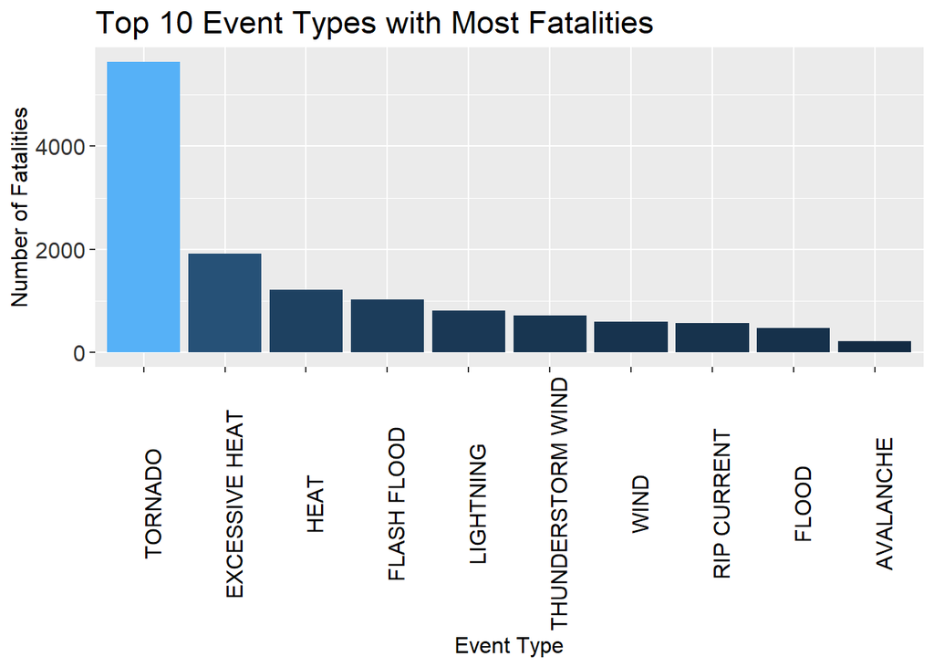

```r
library(ggplot2)
theme <- theme(axis.text.x = element_text(colour = "black", size = 12, angle = 90),
          axis.text.y = element_text(colour = "grey20", size = 12),
          axis.title.x = element_text(size = 12, hjust = .5),
          axis.title.y = element_text(size = 12, hjust = .5, vjust = 1),
          title = element_text(size = 14, hjust = .5)) +
    theme(legend.position = "none")
g <- ggplot(fatal_order[1:10, ], aes(reorder(EVTYPE, -FATALITIES), FATALITIES))
g <- g + geom_bar(stat = "identity", aes(fill = FATALITIES)) +
    xlab("Event Type") + ylab("Number of Fatalities") +
    ggtitle('Top 10 Event Types with Most Fatalities') + theme
print(g)
```

```r
# Arrange in descending order based on the number of fatality rate
fatal_rate_order <- fatal[order(fatal$rate, decreasing = TRUE), ]
# Look at the top 10 event types with highest fatality rate
head(fatal_rate_order, n = 10)
```

```
##                        EVTYPE FATALITIES freq     rate
## MARINE MISHAP   MARINE MISHAP          7    2 3.500000
## ROUGH SEAS         ROUGH SEAS          8    3 2.666667
## TSUNAMI               TSUNAMI         33   20 1.650000
## HEAVY SEAS         HEAVY SEAS          3    2 1.500000
## HEAT                     HEAT       1212  950 1.275789
## HYPOTHERMIA       HYPOTHERMIA          8    7 1.142857
## EXCESSIVE HEAT EXCESSIVE HEAT       1920 1681 1.142177
## COASTALSTORM     COASTALSTORM          1    1 1.000000
## DROWNING             DROWNING          1    1 1.000000
## FREEZING SPRAY FREEZING SPRAY          1    1 1.000000
```

```r
# Determine the number of types of events causing fatalities
(sum(fatal$FATALITIES >= 1))
```

```
## [1] 69
```

### B. Injuries

Looking at the top causes of injuries :

```r
# Aggregate event types by number of injuries
injury <- aggregate(INJURIES ~ EVTYPE, data = st, sum)
# Arrange in descending order based on the number of injuries
injury_order <- injury[order(injury$INJURIES, decreasing = TRUE),]
# Look at the top 10 event types that caused most injuries
head(injury_order, n = 10)
```

```
##                EVTYPE INJURIES
## 232           TORNADO    91407
## 231 THUNDERSTORM WIND     9421
## 49              FLOOD     6795
## 40     EXCESSIVE HEAT     6525
## 103         LIGHTNING     5232
## 67               HEAT     2684
## 259              WIND     1976
## 95          ICE STORM     1975
## 47        FLASH FLOOD     1802
## 258          WILDFIRE     1606
```

`TORNADO` also topped the causes of injuries.

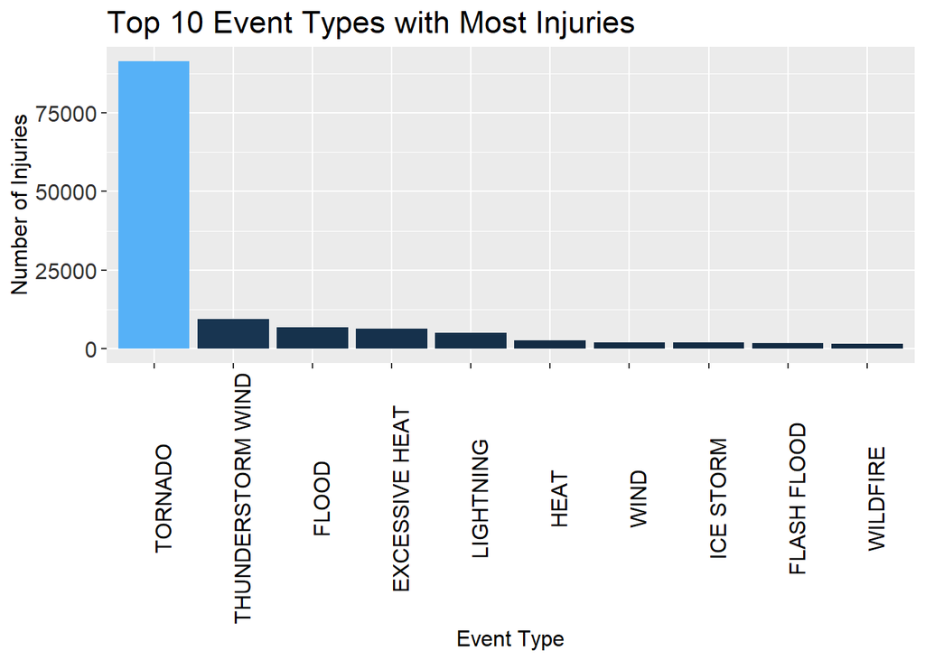

```r
g_in <- ggplot(injury_order[1:10, ], aes(reorder(EVTYPE, -INJURIES), INJURIES))
g_in <- g_in + geom_bar(stat = "identity", aes(fill = INJURIES)) +
    xlab("Event Type") + ylab("Number of Injuries") +
    ggtitle('Top 10 Event Types with Most Injuries') + theme
print(g_in)
```

```r
# Determine the frequency of the event type occcurence
freq <- as.matrix(table(st$EVTYPE))
# Combine the no. of injuries, frequency and fatality rate
injury <- cbind(injury, freq, rate = injury$INJURIES / freq)
# Arrange in descending order based on the number of fatalities
injury_rate_order <- injury[order(injury$rate, decreasing = TRUE), ]
# Look at the top 10 event types with highest fatality rate
head(injury_rate_order, n = 10)
```

```
##                                EVTYPE INJURIES freq     rate
## TSUNAMI                       TSUNAMI      129   20 6.450000
## EXCESSIVE RAINFALL EXCESSIVE RAINFALL       21    4 5.250000
## GLAZE                           GLAZE      231   46 5.021739
## HURRICANE                   HURRICANE     1333  298 4.473154
## EXCESSIVE HEAT         EXCESSIVE HEAT     6525 1681 3.881618
## HEAT                             HEAT     2684  950 2.825263
## MIXED PRECIP             MIXED PRECIP       26   10 2.600000
## MARINE MISHAP           MARINE MISHAP        5    2 2.500000
## ICE                               ICE      137   61 2.245902
## MARINE ACCIDENT       MARINE ACCIDENT        2    1 2.000000
```

```r
# Determine the number of types of events causing injuries
(sum(injury$INJURIES>=1))
```

```
## [1] 63
```

## 3.2 Economic Consequences

### A. Property and Crop Damages

To calculate the damage expenses correctly, First, convert the recorded damage numbers into expenses in dollar unit.

```r
unique(st$PROPDMGEXP)
```

```
##  [1] K M   B m + 0 5 6 ? 4 2 3 h 7 H - 1 8
## Levels:  - ? + 0 1 2 3 4 5 6 7 8 B h H K m M
```

```r
unique(st$CROPDMGEXP)
```

```
## [1]   M K m B ? 0 k 2
## Levels:  ? 0 2 B k K m M
```

```r
idx <- c("", "+", "-", "?", 0:9, "h", "H", "k", "K", "m", "M", "b", "B");
digit <- c(rep(0,4), 0:9, 2, 2, 3, 3, 6, 6, 9, 9)
multi <- data.frame(idx, digit)
st$damage.p <- st$PROPDMG * 10 ^ multi[match(st$PROPDMGEXP, multi$idx), 2]
st$damage.c <- st$CROPDMG * 10 ^ multi[match(st$CROPDMGEXP, multi$idx), 2]
st$damage <- st$damage.p + st$damage.c
dmg.p <- aggregate(damage.p ~ EVTYPE, data = st, sum)
dmg.p_order <- dmg.p[order(dmg.p$damage.p, decreasing = TRUE), ]
dmg.c <- aggregate(damage.c ~ EVTYPE, data = st, sum)
dmg.c_order <- dmg.c[order(dmg.c$damage.c, decreasing = TRUE), ]
dmg <- aggregate(damage ~ EVTYPE, data = st, sum)
dmg_order <- dmg[order(dmg$damage, decreasing = TRUE), ]
```

The figure below shows that `FLOOD` and `HURRICANE` are the top causes of property damages, while `DROUGHT` and `FLOOD` are the top causes of damages on crops. Overall, the `FLOOD` still caused the most economic loss.

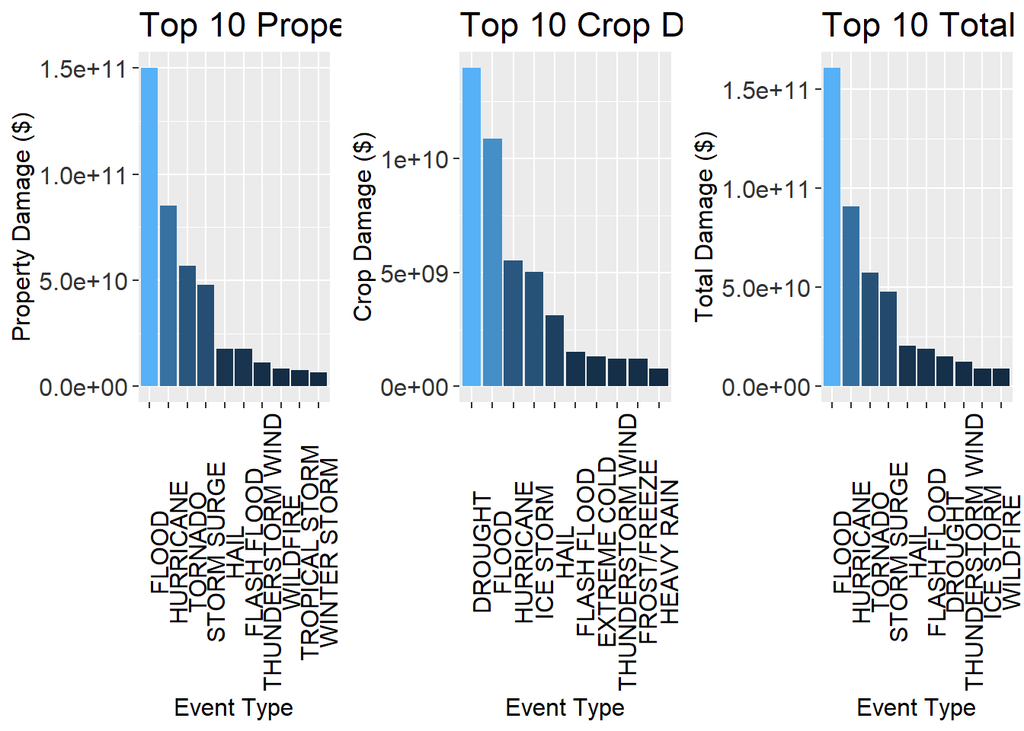

```r
g.p <- ggplot(dmg.p_order[1:10, ], aes(reorder(EVTYPE, -damage.p), damage.p))
g.p <- g.p + geom_bar(stat = "identity", aes(fill = damage.p)) +
    xlab("Event Type") + ylab("Property Damage ($)") +
    ggtitle('Top 10 Property Damage') + theme
g.c <- ggplot(dmg.c_order[1:10, ], aes(reorder(EVTYPE, -damage.c), damage.c))
g.c <- g.c + geom_bar(stat = "identity", aes(fill = damage.c)) +
    xlab("Event Type") + ylab("Crop Damage ($)") +
    ggtitle('Top 10 Crop Damage') + theme
g.t <- ggplot(dmg_order[1:10, ], aes(reorder(EVTYPE, -damage), damage))
g.t <- g.t + geom_bar(stat = "identity", aes(fill = damage)) +
    xlab("Event Type") + ylab("Total Damage ($)") +
    ggtitle('Top 10 Total Damage') + theme
multiplot(g.p, g.c, g.t, cols = 3)
```

# 4. Summary

This project had successfully answered the following questions: